# Marketing Analytics

Homework 1

Armen Mkrtumyan

2025-10-02

```r
options(warn = -1)
library(ggplot2)
library(dplyr)
library(knitr)
library(kableExtra)
```

# Assignment Overview

Every year, *Time* magazine publishes a list of the top 100 innovations of that year. For this assignment, you will:

### 1. Choose an innovation from the list

The link to the 2024 innovations list is [here](https://docs.google.com/spreadsheets/d/17OXyBGSex3BYzAiR1eLlIGdg5_x7YCr55IfDED9USJA/edit?gid=0#gid=0&range=A28:D28). Once you select a product from the list, add its link.

Added - [here](https://docs.google.com/spreadsheets/d/17OXyBGSex3BYzAiR1eLlIGdg5_x7YCr55IfDED9USJA/edit?gid=0#gid=0&range=A28:D28)

### 2. Identify a similar innovation from the past. Reflect on an innovation that resembles the one you’ve chosen. In **1–2 paragraphs**, justify your choice by comparing both innovations in terms of their **functionality, technology, or market impact**.

I will compare it to Tinder(2012) which is a swipe-to-match dating app.

[figure not shown]

The product I have chosen takes dating apps on the next level. It helps its users to write texts and understand each others behaviours - in order to give them appropriate and well thought responses. Both products are intended to improve romantic interactions, but at different stages.

- **Technology**

Tinder’s role was making it easier for people to find matches by introducing mutual-opt-in matching and a mobile-first UI. What Rizz does it uses ChatGPT trained by professional dating coaches to provide suggested responses and other messaging guidances.Tinder was primarily a UX + network effects breakthrough, whereas Rizz is a generative AI/NLP breakthrough layered on today’s dating platforms.

- **Functionality**

Tinder solved the discovery problem, it matches two strangers via swipe-based system (mutually agreed). Rizz solved the next challenge - the conversation itself.

- **Market Impact**

Tinder had 100 million + downloads in Play Store (App store downloads are not public), whereas Rizz had 5 million + downloads in Play Store(App store downloads are not public). Tinder became a huge, worldwide dating marketplace with strong effects. Rizz is much newer, with a smaller share, but In my opinion, it has a huge potential if it works as marketed.

### 3. Find historical data

Use **Statista** (the university provides access through AUA Wi-Fi) or another reliable resource to find a **time series** that matches your look-alike innovation.  
Provide the **reference for the data source**.

I used **Business of Apps** as the primary source for Tinder figures (Business of Apps, 2025),  
and **DemandSage** as a secondary compilation that reproduces those figures (DemandSage, 2025).  
Subscription-rate medians for our *N₀* proxy come from **RevenueCat** (RevenueCat, 2025).

##### Note. DemandSage reproduces figures from Business of Apps;Business of Apps is treated as the primary source and DemandSage as a secondary compilation.

### 4. Estimate Bass Model parameters

Using the time series data for your look-alike innovation, estimate the **Bass diffusion model parameters**:

- Coefficient of innovation (*p*)
- Coefficient of imitation (*q*)
- Market potential (*M*)

```r
df <- read.csv("data/tinder_subscribers.csv")

df$t <- seq_len(nrow(df))

bass_cum <- function(t, p, q, M) {
  M * (1 - exp(-(p + q) * t)) / (1 + (q/p) * exp(-(p + q) * t))
}

fit <- nls(
  subscribers_millions ~ bass_cum(t, p, q, M),
  data = df,
  # M should be > max(df$subscribers_millions), so I will set it to 12. Values
  # of p and q are just starting initial guesses
  start = list(p = 0.02, q = 0.6, M = 12)
)
summary(fit)
```

```
##
## Formula: subscribers_millions ~ bass_cum(t, p, q, M)
##
## Parameters:
##   Estimate Std. Error t value Pr(>|t|)
## p  0.02761    0.01042   2.649   0.0455 *
## q  0.76304    0.16136   4.729   0.0052 **
## M 11.52983    0.77626  14.853  2.5e-05 ***
## ---
## Signif. codes:  0 '***' 0.001 '**' 0.01 '*' 0.05 '.' 0.1 ' ' 1
##
## Residual standard error: 0.5394 on 5 degrees of freedom
##
## Number of iterations to convergence: 6
## Achieved convergence tolerance: 2.999e-06
```

#### We can see from here that p=0.0276 - meaning that each year, a non adopter has 2.76% baseline chance to adopt even if nobody else has adopted. Also q=0.763, meaning that adoption chance increases with the share already adopted. 11.53 for M is 11.53 million estimated market potential.

### 5. Predict the diffusion of the chosen innovation

Based on the **Bass Model**, predict the diffusion path of the chosen innovation.  
Ensure your predictions are **supported with relevant data**.

#### Baseline and scenarios

So we will be using the parameters we got from Tinder data, in order to make assumptions about Rizz app. As a starting point I decided to choose **N0 = 0.105**, since Rizz does not disclose how many of its users are paid users and I had to use some rough estimates:

- in website https://www.revenuecat.com/state-of-subscription-apps-2025/ we have that paid medians are around **1.5% (low-priced apps)** and **2.7% (high-priced apps)**
- we will use midpoint **2.1%**
- **5000000 (Play Store) × 0.021 = 105000**

Lets test 3 scenarious for **M** taking **100 million** as the global ceiling.

- **Conservative:** M = 25 million (Rizz ends up a niche tool)
- **Base:** M = 50 million (Rizz wins meaningful share of daters)
- **Ambitious:** M = 100 million (Rizz becomes the go-to dating assistant for most daters)

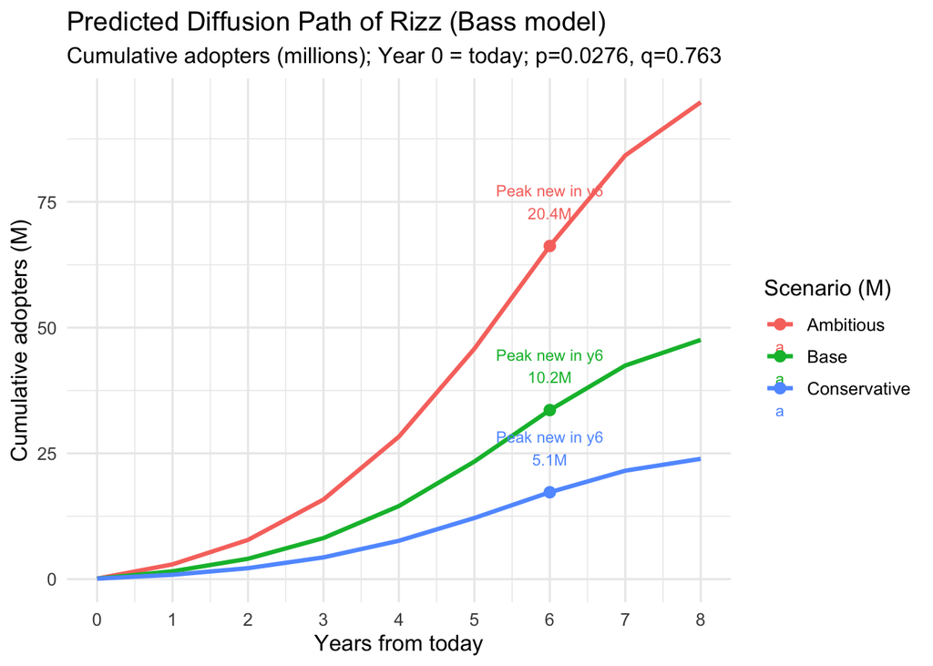

```r
p  <- 0.0276
q  <- 0.763
N0 <- 0.105

forecast_years <- 8
scenarios <- c(Conservative = 25, Base = 50, Ambitious = 100)  # M in millions

make_path <- function(M, p, q, N0, horizon){
  out <- data.frame(year = 0:horizon,
                    new  = rep(NA_real_, horizon + 1),
                    cum  = rep(NA_real_, horizon + 1))
  out$cum[1] <- N0
  for (t in 2:nrow(out)) {
    Nprev      <- out$cum[t - 1]
    out$new[t] <- (p + q * (Nprev / M)) * (M - Nprev)
    out$cum[t] <- Nprev + out$new[t]
  }
  out$M <- M
  out
}

paths <- do.call(rbind, lapply(names(scenarios), function(nm){
  Mval <- as.numeric(scenarios[[nm]])
  df   <- make_path(M = Mval, p = p, q = q, N0 = N0, horizon = forecast_years)
  df$scenario <- nm
  df
}))

paths_round <- paths %>%
  mutate(cum = as.numeric(cum),
         new = as.numeric(new))

peaks <- paths_round %>%
  group_by(scenario) %>%
  slice_max(new, n = 1, with_ties = FALSE)

ggplot(paths_round, aes(x = year, y = cum, color = scenario)) +
  geom_line(linewidth = 1.1) +
  geom_point(data = peaks, aes(x = year, y = cum), size = 2.5) +
  geom_text(
    data = peaks,
    aes(label = paste0("Peak new in y", year, "\n", round(new,1), "M")),
    vjust = -0.8, size = 3
  ) +
  labs(
    title = "Predicted Diffusion Path of Rizz (Bass model)",
    subtitle = "Cumulative adopters (millions); Year 0 = today; p=0.0276, q=0.763",
    x = "Years from today",
    y = "Cumulative adopters (M)",
    color = "Scenario (M)"
  ) +
  scale_x_continuous(breaks = 0:max(paths_round$year)) +
  theme_minimal(base_size = 12)
```

- Conservative (M=25 million)

##### We see it peaks after 6 years, reaching around 5 million customer increase in 1 year(visible also in later tables). Then, as new adopter numbers start to decline, we finally reach 24 million cumulative users by the end of year 8

- Base (M=50 million)

##### We see it peaks after 6 years, reaching around 10 million customer increase in 1 year(visible also in later tables). Then, as new adopter numbers start to decline, we reach 47.5 million cumulative users by the end of year 8

- Ambitious (M=100 million)

##### We see it peaks after 6th year with around 20 million new users increase in 1 year(visible also in later tables). Then, as new adopter numbers starts to decline, as the market gets saturated, by year 8 we approach around 95 million cumulative users.**

### 6. Choose a scope (global or country-specific)

Decide whether to analyze the diffusion **worldwide** or within a **specific country**.  
Justify your choice with **references or data**.

### **Global**

Rizz targets users **across all dating platforms**, not a single market, and **Tinder scaled globally** as well.  
Therefore, we **model diffusion worldwide** and test **different market potential (M) scenarios** reflecting alternative global ceilings.

Primary evidence for Tinder’s global scale comes from Business of Apps (2025); a secondary compilation that reproduces those figures is DemandSage (2025).

### 7. Estimate the number of adopters by period

Using your Bass model parameters, estimate the **number of adopters** of the innovation over time.  
If necessary, use **Fermi’s logic** to make rough estimations in the absence of concrete data.

```r
colnames_to_use <- c("Year","New (M)","Cumulative (M)","M (M)","Scenario")
paths %>%
  filter(scenario == "Conservative") %>%
  kbl(caption = "Conservative", digits = 2, align = "c", row.names = FALSE, col.names = colnames_to_use) %>%
  kable_styling(latex_options = c("striped","hold_position"))
```

Conservative

| Year | New (M) | Cumulative (M) | M (M) | Scenario |
| --- | --- | --- | --- | --- |
| 0 | NA | 0.10 | 25 | Conservative |
| 1 | 0.77 | 0.87 | 25 | Conservative |
| 2 | 1.31 | 2.18 | 25 | Conservative |
| 3 | 2.15 | 4.33 | 25 | Conservative |
| 4 | 3.30 | 7.63 | 25 | Conservative |
| 5 | 4.52 | 12.15 | 25 | Conservative |
| 6 | 5.12 | 17.27 | 25 | Conservative |
| 7 | 4.29 | 21.56 | 25 | Conservative |
| 8 | 2.36 | 23.92 | 25 | Conservative |

```r
paths %>%
  filter(scenario == "Base") %>%
  kbl(caption = "Base Scenario", digits = 2, align = "c", row.names = FALSE, col.names = colnames_to_use) %>%
  kable_styling(latex_options = c("striped","hold_position"))
```

Base Scenario

| Year | New (M) | Cumulative (M) | M (M) | Scenario |
| --- | --- | --- | --- | --- |
| 0 | NA | 0.10 | 50 | Base |
| 1 | 1.46 | 1.56 | 50 | Base |
| 2 | 2.49 | 4.05 | 50 | Base |
| 3 | 4.11 | 8.16 | 50 | Base |
| 4 | 6.37 | 14.53 | 50 | Base |
| 5 | 8.84 | 23.37 | 50 | Base |
| 6 | 10.23 | 33.61 | 50 | Base |
| 7 | 8.86 | 42.47 | 50 | Base |
| 8 | 5.09 | 47.56 | 50 | Base |

```r
paths %>%
  filter(scenario == "Ambitious") %>%
  kbl(caption = "Ambitious Scenario", digits = 2, align = "c", row.names = FALSE, col.names = colnames_to_use) %>%
  kable_styling(latex_options = c("striped","hold_position"))
```

Ambitious Scenario

| Year | New (M) | Cumulative (M) | M (M) | Scenario |
| --- | --- | --- | --- | --- |
| 0 | NA | 0.10 | 100 | Ambitious |
| 1 | 2.84 | 2.94 | 100 | Ambitious |
| 2 | 4.86 | 7.80 | 100 | Ambitious |
| 3 | 8.03 | 15.83 | 100 | Ambitious |
| 4 | 12.49 | 28.32 | 100 | Ambitious |
| 5 | 17.47 | 45.79 | 100 | Ambitious |
| 6 | 20.44 | 66.23 | 100 | Ambitious |
| 7 | 18.00 | 84.22 | 100 | Ambitious |
| 8 | 10.57 | 94.80 | 100 | Ambitious |

## References

Business of Apps. (2025). *Tinder: Revenue and usage statistics 2025*. https://www.businessofapps.com/data/tinder-statistics/

DemandSage. (2025). *Tinder statistics 2025*. https://demandsage.com/tinder-statistics/

RevenueCat. (2025). *State of subscription apps 2025*. https://www.revenuecat.com/state-of-subscription-apps-2025/